# Microbial growth in microplates (Bioscreen/Clario)

Author

Fermlab

# Introduction

This notebook analyzes the growth of microbial cells in microplates. Functions are included that organize data from different plate readers:

- Bioscreen
- Clario
- Tecan (in development)

Input file = excel spreadsheet with 2 pages

1. Page 1 = “Informations”. Plate map describing experiment with these columns. NOTE: empty wells are written as “empty” in all columns except Well.
   1. Well: microtiter plate well
   2. Strain
   3. Medium: growth medium
   4. Treatment: carbon source, etc
   5. Dilution: dilution of cells into microtiter plate. For example 1/20 = 0.05
2. Page 2 = “Raw data”. Data from plate reader

# Setup

## File I/O

```r
# input data
file.in = "growthData_Clario.xlsx";
path.in = "/home/tolonen/Github/actolonen/Public/Analysis_Lab/Growth/Microplates/Data";
data.in = paste(path.in, file.in, sep = "/");
```

## Functions

### Functions to organize data

These functions take data from a specific type of plate reader and returns a data.frame with the following columns:

1. Hours
2. Well in microtiter plate
3. OD600
4. Strain (write “Blank” for lack of cells)
5. Dilution: dilution of cells into fresh medium in microtiter plate. For example, a 1/20 dilution = 0.05
6. Growth medium
7. Treatment (ie different carbon sources)

Function to organize Clario data

```r
organize_clario = function(data.in)
{
# output is data.frame = [Hours, Well, OD600, Treatment]

plate.map = read_excel(data.in, sheet = "Informations", col_names = TRUE, skip = 3);
growth.data = read_excel(data.in, sheet = "Raw data", col_names = TRUE, skip = 0);

# plate map variables
first.well = "A01";
last.well = "H12";

# parse plate.map
plate.map = plate.map %>%
  filter(!Treatment == "Empty");

# parse growth.data
growth.data.long = growth.data %>%
  select(-Well) %>%
  rename("Time" = "...2") %>%
  slice(-1) %>% # delete first row
  slice(-1) %>%
  mutate(Time = if_else(grepl("min", Time), true = Time, false =  paste(Time, "0 min", sep = " "))) %>%
# add minutes field where lacking
  separate(Time, c("my.hours", "hours.label", "my.min", "min.label"), sep = " ") %>%
  mutate(Hours = as.numeric(my.hours) + as.numeric(my.min)/60) %>%
  #mutate(Seconds = as.numeric(Seconds)) %>%
  #mutate(Hours = Seconds/3600) %>%
  dplyr::select(Hours, first.well:last.well) %>%
  pivot_longer(cols = first.well:last.well, names_to = "Well", values_to = "OD600");
growth.data.long$OD600 = as.numeric(growth.data.long$OD600);

# add treatment info
growth.all = inner_join(growth.data.long, plate.map, by = "Well");

growth.all = growth.all %>%
    select(Well, Hours, OD600, Strain, Medium, Treatment, Dilution)

return(growth.all)
}
```

Function to organize Bioscreen data

```r
organize_bioscreen = function(data.in)
{
# output is data.frame = [Hours, Well, OD600, Treatment]

plate.map = read_excel(data.in, sheet = "Informations", col_names = TRUE, skip = 4);
growth.data = read_excel(data.in, sheet = "Raw data", col_names = TRUE, skip = 2);

# plate map variables
first.well = "2";
last.well = "199";

# parse plate.map
plate.map = plate.map %>%
  filter(!Treatment == "Empty") %>%
  mutate(Well = as.character(Well));

# calculate elapsed time in hours
time1 = hms("00:00:00"); # start time
growth.data = growth.data %>%
  mutate(Time_hms = hms(Time)) %>%
  mutate(Time_Elapsed = Time_hms - time1) %>%
  mutate(Hours = hour(Time_Elapsed) +
         (minute(Time_Elapsed) / 60) +
         (second(Time_Elapsed)/3600));

growth.data.long = growth.data %>%
  select(-Blank) %>%
  dplyr::select(Hours, first.well:last.well) %>%
  pivot_longer(cols = first.well:last.well, names_to = "Well", values_to = "OD600");
growth.data.long$OD600 = as.numeric(growth.data.long$OD600);

# remove contaminated wells
#growth.data.long = growth.data.long %>%
#  filter(!Well %in% c("A04", "A05", "A06", "C03", "E02", "G01", "G04", "G05"));

# add treatment info
growth.all = inner_join(growth.data.long, plate.map, by = "Well");

growth.all = select(growth.all, Well, Hours, OD600, Strain, Medium, Treatment, Dilution);

return(growth.all)
}
```

### Functions to normalize OD600 data

Function to normalize OD600 readings by subtracting OD600 at time zero

```r
# Function to normalize OD600 readings by subtracting the OD600 at t=0h

norm_initial = function(growth.cells)
{

# find first timepoint
min_time = min(growth.cells$Hours);

# calc initial OD600
initial.OD = growth.cells %>%
  filter(Hours == min_time) %>%
  rename(OD600_t0 = OD600) %>%
  select(Well, OD600_t0);

# normalize OD600 by subtracting initial reading
growth.cells = left_join(growth.cells, initial.OD, by = "Well");
growth.cells = growth.cells %>%
  mutate(OD600 = OD600 - OD600_t0) %>%
  select(-OD600_t0);

return(growth.cells);
}
```

Function to normalize OD600 readings by subtracting mean OD600 at the same time point

```r
# substract blank mean from OD measurements

norm_mean = function(growth.blanks, growth.cells)
{
# calc mean blank
growth.blanks = growth.blanks %>%
    group_by(Hours)%>%
        mutate(OD600_blank = mean(OD600)) %>%
    ungroup;

growth.blanks = growth.blanks %>%
    select(Hours, OD600_blank) %>%
    distinct();

# subtract mean blank
growth.cells = left_join(growth.cells, growth.blanks, by = c("Hours"));
growth.cells = growth.cells %>%
    mutate(OD600_norm = OD600 - OD600_blank);

return(growth.cells);
}
```

# Main

## Organize data

```r
if (plate_reader == "Clario")
{
  growth.all = organize_clario(data.in);
}
if (plate_reader == "Bioscreen")
{
  growth.all = organize_bioscreen(data.in);
}

growth.short = head(growth.all, 5);
table.growth = kable(growth.short, caption = "Table: tidy growth data");
table.growth
```

Table: tidy growth data

| Well | Hours | OD600 | Strain | Medium | Treatment | Dilution |
| --- | --- | --- | --- | --- | --- | --- |
| A01 | 0 | 0.407 | WT | GS2 | 0% butanol | 0.1 |
| A02 | 0 | 0.301 | WT | GS2 | 0% butanol | 0.1 |
| A03 | 0 | 0.346 | WT | GS2 | 0% butanol | 0.1 |
| A04 | 0 | 2.126 | Blank | GS2 | 0% butanol | 0 |
| A05 | 0 | 1.754 | Blank | GS2 | 0% butanol | 0 |

## Plot Individual wells

Plot blanks

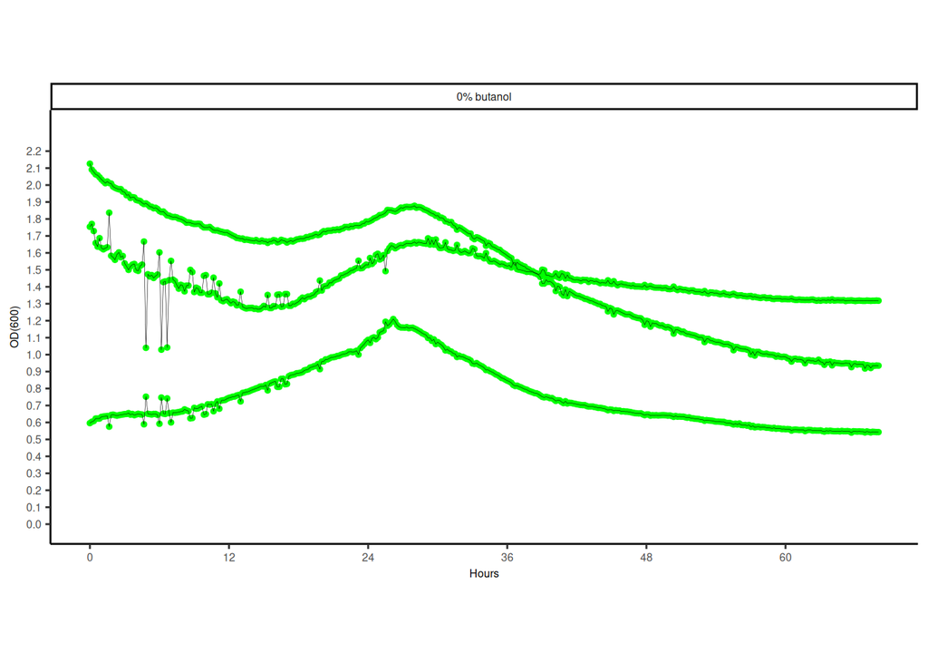

Fig 1. OD600 of blank treatments (no cells). Each curve is a well.

```r
growth.blanks = growth.all %>%
  filter(grepl("Blank", Strain));

plot.blanks = ggplot(growth.blanks, aes(x=Hours, y=OD600, group=Well)) +
  geom_point(size=1, color = "green") +
  geom_line(linewidth=0.1, color='black') +
  theme_bw() +
  xlab("Hours") +
  ylab("OD(600)") +
  coord_cartesian(
    xlim = c(0, max(growth.blanks$Hours)),
    ylim = c(0, max(growth.blanks$OD600) + 0.2))+
  facet_wrap (~Treatment, ncol=3)+
  scale_x_continuous(breaks=seq(0, max(growth.blanks$Hours), 12))+
  scale_y_continuous(breaks=seq(0, max(growth.blanks$OD600 + 0.1), 0.1))+
  theme_classic()+
  mytheme;

grid.arrange(plot.blanks, ncol=1);
```

Remove contaminated wells

```r
growth.all = growth.all %>%
    filter(!Well %in% c("114", "104", "175"));
```

Normalize OD600 data: subtract blanks from wells with cells.

```r
# focus on well with cells
growth.cells = growth.all %>%
  filter(!grepl("Blank|Empty", Strain));

if (norm_OD600 == "mean")
{
  growth.cells = norm_mean(growth.blanks, growth.cells);
}
if (norm_OD600 == "initial")
{
  growth.cells = norm_initial(growth.cells);
}
```

Plot growth in well with cells

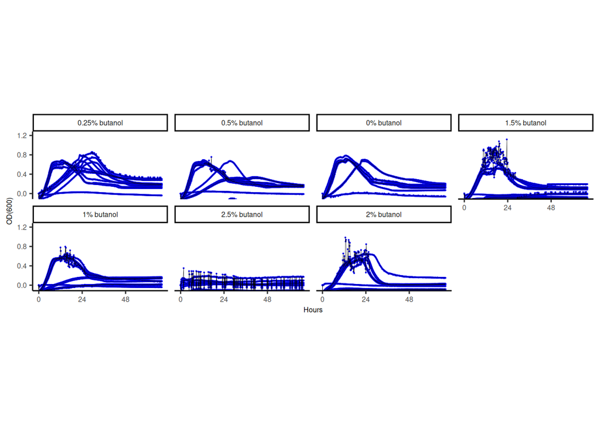

Fig 2. Growth (OD600) of treatments with cells. Each curve is a well.

```r
plot.cells = ggplot(growth.cells, aes(x=Hours, y=OD600, group=Well)) +
  geom_point(size=.05, color = "blue") +
  geom_line(linewidth=0.1, color='black') +
  theme_bw() +
  xlab("Hours") +
  ylab("OD(600)") +
  coord_cartesian(
    xlim = c(0, max(growth.cells$Hours)),
    ylim = c(-0.05,  max(growth.cells$OD600) + 0.1))+
  facet_wrap (~Treatment, ncol=4)+
  scale_x_continuous(breaks=seq(0, max(growth.cells$Hours), 24))+
  scale_y_continuous(breaks=seq(0, max(growth.cells$OD600 + 0.1), 0.4))+
  theme_classic()+
  mytheme;

grid.arrange(plot.cells, ncol=1);
```

## Compare treatment means on same plot

Calc treatment means

```r
growth.cells = growth.cells %>%
  group_by(Hours, Treatment) %>%
  mutate(OD600_mean = mean(OD600)) %>%
  mutate(OD600_sd = sd(OD600)) %>%
ungroup();
```

Plot treatment means

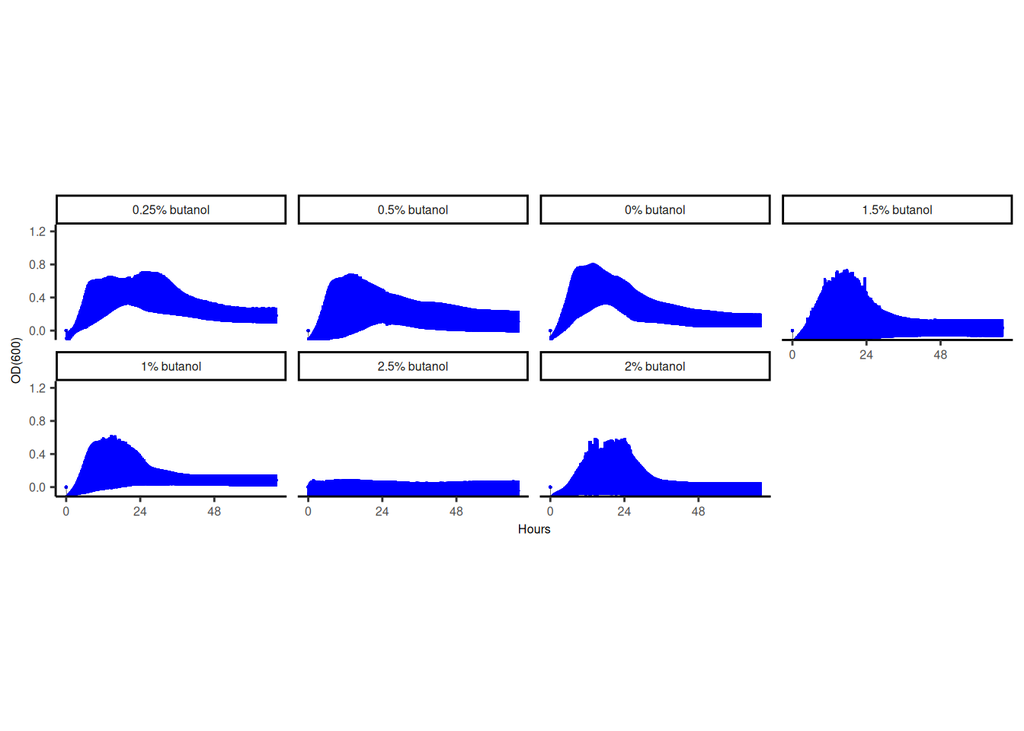

Fig 3. Growth (OD600) of treatments with cells. Plot shows treatment means +/-SD.

```r
plot.cells.means = ggplot(growth.cells, aes(
    x=Hours,
    y=OD600_mean,
    ymin = OD600_mean - OD600_sd,
    ymax = OD600_mean + OD600_sd)) +
  geom_point(size=.05, color = "blue") +
  geom_line(linewidth=0.1, color='black') +
  geom_errorbar(width = 0, color = "blue")+
  theme_bw() +
  xlab("Hours") +
  ylab("OD(600)") +
  coord_cartesian(
    xlim = c(0, max(growth.cells$Hours)),
    ylim = c(-0.05,  max(growth.cells$OD600) + 0.1))+
  facet_wrap (~Treatment, ncol=4)+
  scale_x_continuous(breaks=seq(0, max(growth.cells$Hours), 24))+
  scale_y_continuous(breaks=seq(0, max(growth.cells$OD600 + 0.1), 0.4))+
  theme_classic()+
  mytheme;

grid.arrange(plot.cells.means, ncol=1);
```

Compare treatment means for each strain

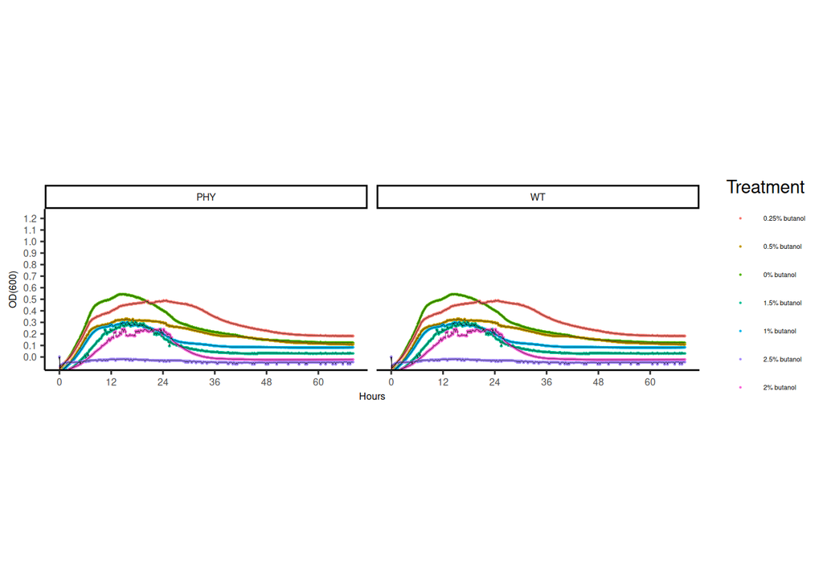

Fig 4. Growth (OD600) of treatments with cells growing in different treatments. Plot shows treatment means.

```r
plot.cells_strains = ggplot(growth.cells, aes(
    x=Hours,
    y=OD600_mean,
    group=Treatment,
    color=Treatment))+
    #ymin = OD600_mean - OD600_sd,
    #ymax = OD600_mean + OD600_sd)) +
  geom_point(size=.05) +
  geom_line(linewidth=0.1, color='black') +
  #geom_errorbar(width = 0, color = "blue")+
  facet_wrap(~ Strain)+
  theme_bw() +
  xlab("Hours") +
  ylab("OD(600)") +
  coord_cartesian(
    xlim = c(0, max(growth.cells$Hours)),
    ylim = c(-0.05,  max(growth.cells$OD600) + 0.1))+
  scale_x_continuous(breaks=seq(0, max(growth.cells$Hours), 12))+
  scale_y_continuous(breaks=seq(0, max(growth.cells$OD600 + 0.1), 0.1))+
  theme_classic()+
  mytheme;

grid.arrange(plot.cells_strains, ncol=1);
```